# **Regresión Lineal**

- María Camila Góngora Albán, mcgongoraa@unal.edu.co

# 1. Introducción

Al observar diferentes fenómenos o situaciones en diferentes disciplinas (Economía, Sociología, Salud, entre otros), es natural cuestionarse respecto a la posible relación existente entre dos sucesos. Al intentar responder estos cuestionamientos, se obtiene una mayor comprensión del fenómeno y se obtienen herramientas para toma de decisiones, según sea el caso. Estepa et al (2012) refuerzan este concepto al citar a Croecker: “*Conocer si los sucesos se relacionan y, con qué intensidad lo hacen, facilita a las personas explicar el pasado, controlar el presente y predecir el futuro*” (Crocker, 1981, p.272)

Como ejemplo de su utilidad se presenta la siguiente situación: La figura a continuación, muestra las ventas (en miles de unidades) de un producto en particular, en función de los presupuestos publicitarios (en miles de dólares) para los medios de televisión, radio y periódicos. A partir de esta información se debe diseñar el plan de publicidad del próximo año. James, G. et al. (2013)

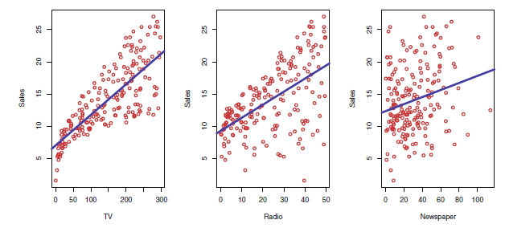

Tomado de James, G. et al. (2013)

Bajo este panorama surgen los siguientes cuestionamientos:

- ¿Existe una relación entre el presupuesto publicitario y las ventas?
- ¿Qué tan fuerte es la relación entre el presupuesto publicitario y las ventas?
- ¿Qué medios publicitarios contribuyen a las ventas?
- ¿Con qué precisión podemos estimar el efecto de cada medio publicitario en las ventas?
- ¿La relación es lineal?

Estas preguntas se pueden resolver, por ejemplo, a través de la Regresión Lineal.

# 2. Historia

Los primeros aportes que se realizaron y de los cuales surgió la Regresión Lineal estuvieron asociados a la Correlación entre variables en problemas de Biología, Biometría y Eugenesia.

El primer autor que se interesó en el tema fue Lambert-Adolphe-Jacques Quetelet (1796-1874), sus aportes sobre la correlación y regresión se originaron en sus estudios sobre el hombre medio, estimando empíricamente las medias y desviaciones típicas de medidas antropométricas, las cuales suponía que dependen de varias variables independientes tales como el sexo, edad, profesión o nivel de educación. Estepa, A. et al. (2012)

Otro personaje que se interesó por el tema fue Francis Galton (1822-1911) estudió Medicina y Matemáticas, sin embargo, no era conocedor de los métodos estadísticos de la época (usados, por ejemplo, por Laplace y Gauss). Por medio de investigaciones empíricas, estudió la variabilidad de características humanas. Su inspiración fue el evidenciar que los hijos de padres muy altos tendían a ser más bajos que sus padres y los hijos de padres muy bajos tendían a ser más altos que sus padres. Era como si una fuerza misteriosa estuviera provocando que las alturas humanas se alejaran de los extremos y se acercaran a la media o media de todos los humanos. Galton llamó a este fenómeno "*regresión a la media*". Salsburg, D. (2002)

[figure not shown]

Pearson continúa el trabajo de Galton, interesado en la Biometría debido a los trabajos de éste y de Weldon, quien en 1892 fue el primero que publicó un artículo en el que señala el significado de un coeficiente de correlación negativo.

Las ideas modernas sobre regresión se originan en los trabajo de Legendre y Gauss, sobre el método de mínimos cuadrados, para ajustar los datos sobre las órbitas de cuerpos celestes.

En 1829 Gauss fue capaz de establecer la razón por la cual este procedimiento es muy adecuado desde el punto de vista estadístico, mediante lo que hoy se conoce como teorema de Gauss-Markov, que muestra que los estimadores obtenidos con este método son insesgados y no se requiere una distribución específica para los datos que se ajustan. El impulso posterior lo dan los trabajos citados de Galton y Pearson sobre la herencia. Yule la utiliza para el estudio de fenómenos sociales, como las causas de pobreza alrededor de 1899.

Alrededor de 1895, Pearson había resuelto las propiedades matemáticas del coeficiente de correlación y la regresión simple utilizada para la predicción lineal entre dos variables continuas. También generaliza la idea de regresión de Galton a varias dimensiones, comprobando que muchas variables biométricas siguen la distribución normal multivariante y por tanto se podría aplicar la regresión múltiple para relacionar varias de estas medidas. Estepa, A. et al. (2012)

# 3. Algoritmo

Esta sección se basa en James, G. et al. (2013)

Bajo la regresión lineal simple, se pretende obtener una respuesta cuantitativa $Y$ sobre la base de una única variable predictora de regresión $X$. Se supone que hay aproximadamente una relación lineal entre $X$ y $Y$. Lo anterior, se puede escribir matemáticamente de la siguiente forma:

$$Y= \beta_{0} + \beta_{1} X + \epsilon \text{, con } E(\epsilon)=0 \text{ y } V(\epsilon)=\sigma^{2}$$

donde, $Y$ es la variable respuesta dependiente, $X$ la variable regresora independiente, $\beta_{0}$ y $\beta_{1}$ parámetros o coeficientes del modelo (constantes desconocidas) y $\epsilon$ vector de errores.

De tal forma que al estimar los parámetros, se puede obtener $\hat{y}$ el cual indica una predicción de $Y$ sobre la base de $X = x$.

$$\hat{y} = \hat{\beta}_{0} + \hat{\beta}_{1} x$$

Pero en la práctica $\beta_{0}$ y $\beta_{1}$ son desconocidos, así que ¿de qué forma se obtinen las estimaciones para estos parámetros?

## 3.1 Estimación

Sean $(x_{1},y_{1}),\text{ } (x_{2},y_{2}),\text{ } ...,\text{ } (x_{n},y_{n})$, $n$ pares de observaciones, cada uno de los cuales consta de una medida de $X$ y una medida de $Y$.

El objetivo es obtener estimaciones de coeficientes $\hat{\beta}_{0}$ y $\hat{\beta}_{1}$ de manera que el modelo lineal presentado, se ajuste bien a los datos disponibles. En otras palabras, encontrar una intersección $\hat{\beta}_{0}$ y una pendiente $\hat{\beta}_{1}$ tal que la línea resultante esté lo más cerca posible de los $n$ puntos de datos.

# 3.1.1 Estimación Mínimos Cuadrados

El ajuste se encuentra minimizando la suma de errores cuadrados. La expresión $e_{i}=y_{i}-\hat{y}_{i}$ representa el i-ésimo residuo: esta es la diferencia entre el i-ésimo valor de respuesta observado y el i-ésimo valor de respuesta que predice nuestro modelo lineal.

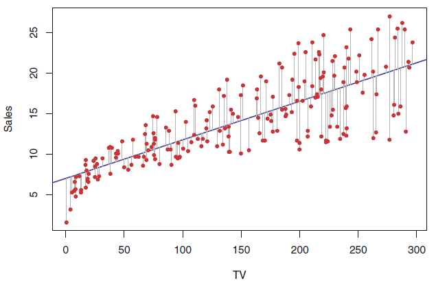

Tomado de James, G. et al. (2013)

$$\hat{\beta}_{0} = \bar{y} - \hat{\beta}_{1}\bar{x}$$

donde $\bar{y} = \dfrac{1}{n} \sum_{i=1}^{n}y_{i}$ y $\bar{x} = \dfrac{1}{n} \sum_{i=1}^{n}x_{i}$ son las medias muestrales.

En el ejemplo que se presenta en la siguiente sección se verá gráficamente la optimización realizada para encontrar $\hat{\beta}_{0}$ y $\hat{\beta}_{1}$ a través de los gráficos de contorno y tridimensionales del RSS.

Posterior al ajuste del modelo, es necesario evaluar la precisión de las estimaciones de coeficientes y determinar si la relación existente entre las dos variables puede ser descrita de forma adecuada por el modelo. La verdadera relación probablemente no sea lineal o pueden existir otras variables que causen variación en $Y$.

Además, se debe evaluar la precisión del modelo, pues es natural querer cuantificar la medida en que el modelo se ajusta a los datos. La calidad de un ajuste de regresión lineal generalmente se evalúa utilizando dos cantidades relacionadas: el error estándar residual $(RSE)$ y la estadística $R^{2}$.

La regresión lineal simple es un enfoque útil para predecir una respuesta sobre la base de una única variable predictora. Sin embargo, en la práctica, a menudo tenemos más de un predictor. En este caso, se extienden los resultados de la Regresión Lineal Simple de tal forma que pueda considerar los múltiples predictores, a esta metodología se le conoce como Regresión Lineal Múltiple.

Cuando ajustamos un modelo de regresión lineal a un conjunto de datos en particular, muchos problemas pueden ocurrir. Los más comunes entre estos son los siguientes:

1. No linealidad de las relaciones respuesta-predictor.
2. Correlación de términos de error. Un supuesto importante del modelo de regresión lineal es que los términos de error, $e_{1}, e_{2}, · · ·, e_{n}$, no están correlacionados.
3. Varianza no constante de los términos de error. El supuesto del modelo de regresión lineal es que los términos de error tienen una varianza constante. Los errores estándar, los intervalos de confianza y las pruebas de hipótesis asociados con el modelo lineal se basan en este supuesto.
4. Valores atípicos.
5. Colinealidad. La colinealidad se refiere a la situación en la que dos o más variables predictoras están estrechamente relacionadas entre sí.

En la práctica, identificar y superar estos problemas es tanto un el arte como ciencia.

# 4. Ejemplo

Continuando con la situación presentada en la introducción, se tiene un conjunto de datos publicitarios con 200 registros y cuatro variables:

- Sales: ventas (en miles de unidades) de un producto en particular
- TV: Presupuestos publicitarios (en miles de dólares) para televisión
- Radio: Presupuestos publicitarios (en miles de dólares) para radio
- Newspaper: Presupuestos publicitarios (en miles de dólares) para periódicos

Consiste en las ventas de un producto en particular en 200 mercados diferentes, junto con los presupuestos publicitarios del producto en cada uno de esos mercados para tres medios de comunicación diferentes: televisión, radio y periódicos.

El objetivo es identificar de qué forma los presupuestos en cada uno de los medios de comunicación pueden incrementar las ventas del producto.

Este ejemplo está basado en el código asociado al libro An Introduction to Statistical Learning with Applications in R, James, G. et al. (2013).

```python
# Cargar las librerías
import pandas as pd
import numpy as np
import matplotlib.pyplot as plt
from mpl_toolkits.mplot3d import axes3d
import seaborn as sns

from sklearn.preprocessing import scale
import sklearn.linear_model as skl_lm
from sklearn.metrics import mean_squared_error, r2_score
import statsmodels.api as sm
import statsmodels.formula.api as smf

%matplotlib inline
plt.style.use('seaborn-white')
```

```python
# Cargar la base de datos
advertising = pd.read_csv('/content/drive/MyDrive/Colab Notebooks/UN_Mineria_de_datos/Tareas/Ensayo Reg Lineal/Advertising.csv', usecols=[1,2,3,4])
advertising.info()
```

```
<class 'pandas.core.frame.DataFrame'>
RangeIndex: 200 entries, 0 to 199
Data columns (total 4 columns):
 #   Column     Non-Null Count  Dtype
---  ------     --------------  -----
 0   TV         200 non-null    float64
 1   Radio      200 non-null    float64
 2   Newspaper  200 non-null    float64
 3   Sales      200 non-null    float64
dtypes: float64(4)
memory usage: 6.4 KB
```

En el siguiente gráfico se presenta la distribución de las ventas en función del presupuesto publicitario para televisión y se ajusta una recta al comportamiento. Sin embargo, más adelante se verá la estimación de los parámetros.

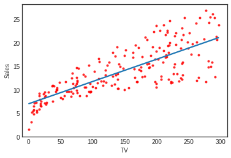

```python
sns.regplot(advertising.TV, advertising.Sales, order=1, ci=None, scatter_kws={'color':'r', 's':9})
plt.xlim(-10,310)
plt.ylim(ymin=0);
```

A continuación se realiza el ajuste y se presentan las estimaciones $\hat{\beta}_{0}$ y $\hat{\beta}_{1}$ obtenidas bajo la optimización presentada en la anterior sección.

```python
# Coeficientes de Regresión (Mínimos Cuadrados Ordinarios)
regr = skl_lm.LinearRegression()

# Se centra la variable TV y se definen variables
#X = scale(advertising.TV, with_mean=True, with_std=False).reshape(-1,1)
# Sin centrar la variable TV y se definen variables
X = scale(advertising.TV, with_mean=False, with_std=False).reshape(-1,1)
y = advertising.Sales

# Ajuste de la regresión lineal
regr.fit(X,y)
print("La estimación para beta_0 es: ",regr.intercept_)
print("La estimación para beta_1 es: ",regr.coef_)
```

```
La estimación para beta_0 es:  7.032593549127695
La estimación para beta_1 es:  [0.04753664]
```

La función cuadrática objeto de la optimización, se puede ver representada a continuación. De esta forma se ve gráficamente el punto $(\beta_{0},\beta_{1})$ que hace mínima la expresión RSS.

```python
# Crea las coordenadas de la grilla para graficar
B0 = np.linspace(regr.intercept_-2, regr.intercept_+2, 50) # se generan 50 números comprendidos entre +- 2 alrededor de beta_0
B1 = np.linspace(regr.coef_-0.02, regr.coef_+0.02, 50) # se generan 50 números comprendidos entre +- 0.02 alrededor de beta_1
xx, yy = np.meshgrid(B0, B1, indexing='xy') # retorna las coordenadas matriciales en x y en y
Z = np.zeros((B0.size,B1.size)) # crea matriz de 0 de tamaño 50x50

# Calcula los valores Z (RSS) basado en la grilla construida
for (i,j),v in np.ndenumerate(Z):
    Z[i,j] =((y - (xx[i,j]+X.ravel()*yy[i,j]))**2).sum()/1000

# Minimized RSS
min_RSS = r'$\beta_0$, $\beta_1$ for minimized RSS'
min_rss = np.sum((regr.intercept_+regr.coef_*X - y.values.reshape(-1,1))**2)/1000
print("El valor mínimo para esta función es ",min_rss)
```

```
El valor mínimo para esta función es  2.1025305831313514
```

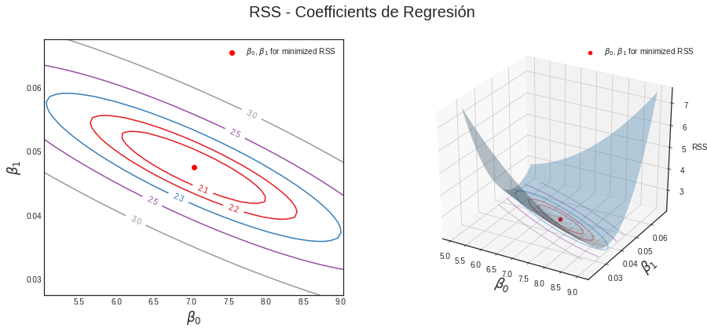

```python
fig = plt.figure(figsize=(15,6))
fig.suptitle('RSS - Coefficients de Regresión', fontsize=20)

# crea los esqueletos para los gráficos
ax1 = fig.add_subplot(121)
ax2 = fig.add_subplot(122, projection='3d')

# Gráfico de contorno
CS = ax1.contour(xx, yy, Z, cmap=plt.cm.Set1, levels=[2.15, 2.2, 2.3, 2.5, 3])
ax1.scatter(regr.intercept_, regr.coef_[0], c='r', label=min_RSS)
ax1.clabel(CS, inline=True, fontsize=10, fmt='%1.1f')

# Gráfico tridimensional
ax2.plot_surface(xx, yy, Z, rstride=3, cstride=3, alpha=0.3)
ax2.contour(xx, yy, Z, zdir='z', offset=Z.min(), cmap=plt.cm.Set1,
            alpha=0.4, levels=[2.15, 2.2, 2.3, 2.5, 3])
ax2.scatter3D(regr.intercept_, regr.coef_[0], min_rss, c='r', label=min_RSS)
ax2.set_zlabel('RSS')
ax2.set_zlim(Z.min(),Z.max())
ax2.set_ylim(0.02,0.07)

# ajuste para los dos gráficos
for ax in fig.axes:
    ax.set_xlabel(r'$\beta_0$', fontsize=17)
    ax.set_ylabel(r'$\beta_1$', fontsize=17)
    ax.set_yticks([0.03,0.04,0.05,0.06])
    ax.legend()
```

En la siguiente tabla se presentan las estimaciones junto con algunas estadísticas, de aquí se puede concluir que la variable de Presupuesto publicitario para televisión resulta ser significativa en la estimación de las ventas del producto.

Según las estimaciones, $ 1,000 adicionales gastados en publicidad televisiva están asociados con la venta de aproximadamente 47.5 unidades adicionales del producto.

```python
est = smf.ols('Sales ~ TV', advertising).fit()
est.summary().tables[1]
```

|  | coef | std err | t | P>\|t\| | [0.025 | 0.975] |
| --- | --- | --- | --- | --- | --- | --- |
| Intercept | 7.0326 | 0.458 | 15.360 | 0.000 | 6.130 | 7.935 |
| TV | 0.0475 | 0.003 | 17.668 | 0.000 | 0.042 | 0.053 |

```python
Sales_pred = regr.predict(X)
print("El R2 es: ",r2_score(y, Sales_pred))
```

```
El R2 es:  0.611875050850071
```

# 5. Conclusiones

La regresión lineal simple, es de las metodologías más sencillas y ampliamente usadas para resolver problemas en diferentes áreas. Incluso en ocasiones se abusa de ella llevandola a aplicaciones donde no necesariamente es pertinente su uso. Al aplicarla es necesario tener en cuenta cada uno de los supuestos y consideraciones correspondientes para llegar a resultados satisfactorios y válidos.

Dentro de la descripción, en secciones anteriores, se mencionaron algunos problemas que puede presentar la regresión lineal, como por ejemplo: No linealidad de las relaciones respuesta-predictor; Correlación de términos de error; Varianza no constante de los términos de error; Valores atípicos; y Colinealidad. Por lo cual se debe ser muy cuidadoso y aplicar los diferentes análisis y pruebas.

Se puede decir que es una metodología antigua, con más de 200 años, pero que se mantiene vigente y ha sido base para la construcción de otras metodologías.

# Referencias

1. Estepa, A. et al. (2012) Algunas notas históricas sobre la correlación y regresión y su uso en el aula. *Números. Revista de Didáctica de las Matemáticas* Volumen 81, páginas 5-14. ISSN: 1887-1984. Consultado en: [PDF](https://core.ac.uk/download/pdf/20343739.pdf)
2. James, G. et al. (2013) An Introduction to Statistical Learning with Applications in R. Springer Texts in Statistics, DOI 10.1007/978-1-4614-7138-7 3, © Springer Science+Business Media New York [PDF](https://www.statlearning.com/)
3. Salsburg, D. (2002). The Lady Tasting Tea: How Statistics Revolutionized Science in the Twentieth Century. Henry Holt and Company. ISBN=9781466801783 [URL](https://books.google.com.ni/books?id=VCw\_RxBrJc8C)
4. Advertising.csv Consultada en: [CSV](https://www.kaggle.com/bumba5341/advertisingcsv?select=Advertising.csv)
5. Código Chapter 3 - Linear Regression. ISLR-python [HTML](https://nbviewer.jupyter.org/github/JWarmenhoven/ISL-python/blob/master/Notebooks/Chapter%203.ipynb#Load-Datasets)